# MODULE 5 WEEK 2

# Loading and preprocessing the data

1. Load the data
2. Process/transform the data (if necessary) into a format suitable for your analysis

```r
data_input<-read.table("activity.csv",sep=",",header=TRUE)
```

Then, for processing the dates as “Date” variable, it needs to be transformed into date format which is done as follows -

```r
# processing data
data_input$date <- as.Date(data_input$date)
```

### 1. Calculate the total number of steps taken per day

```r
steps_day<-tapply(data_input$steps,data_input$date,sum,na.rm=TRUE)
```

### 2. Make a histogram of the total number of steps taken each day

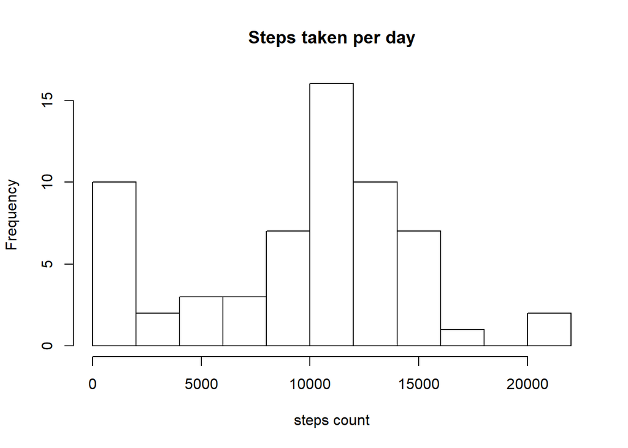

```r
hist(steps_day, breaks = 8, xlab = "steps count", main = "Steps taken per day")
```

### 3. Calculate and report the mean and median of the total number of steps taken per day

```r
mean_steps<-mean(steps_day,na.rm=TRUE)
median_steps<-median(steps_day,na.rm=TRUE)
mean_steps
```

```
## [1] 9354.23
```

```r
median_steps
```

```
## [1] 10395
```

## What is the average daily activity pattern?

We want to create a time series plot for the step count in each interval.

- First, interval-wise average step count need to be calculated
- Second, plotting the required figure

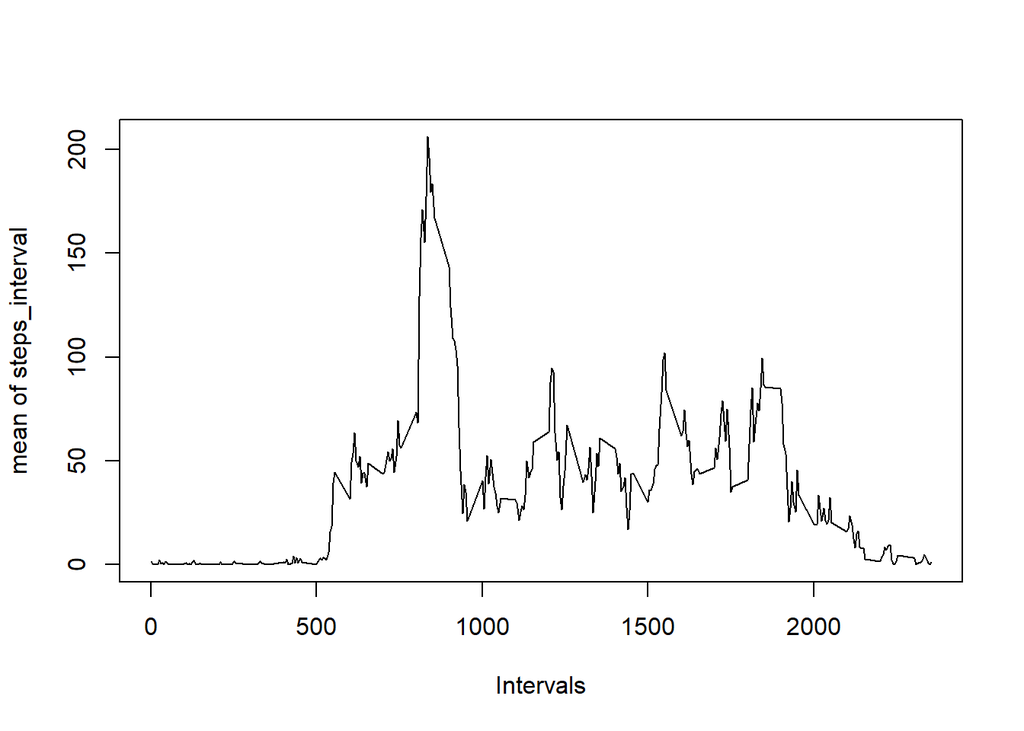

```r
steps_interval<-tapply(data_input$steps,data_input$interval,mean,na.rm=TRUE)
plot(x=names(steps_interval),y=steps_interval,type="l",xlab="Intervals",ylab="mean of steps_interval")
```

```r
max_steps_interval<-max(steps_interval)
max_steps_interval
```

```
## [1] 206.1698
```

# Imputing missing values

Note that there are a number of days/intervals where there are missing values (coded as **NA**). The presence of missing days may introduce bias into some calculations or summaries of the data.

## Calculate and report the total number of missing values in the dataset (i.e. the total number of rows with NA)

```r
total_NA<-sum(is.na(data_input$steps))
total_NA
```

```
## [1] 2304
```

## Filling in all of the missing values in the dataset with the mean for that 5-minute interval and Create a new dataset called data_input_2 that is equal to the original dataset but with the missing data filled in

```r
df<-data.frame(interval=as.numeric(as.character(names(steps_interval))),steps_avg_interval=steps_interval)
data_input_2<-merge(data_input,df,by="interval",all.x=TRUE)
data_input_2[is.na(data_input_2$steps),]$steps<-data_input_2[is.na(data_input_2$steps),]$steps_avg_interval
```

### Make a histogram of the total number of steps taken each day.

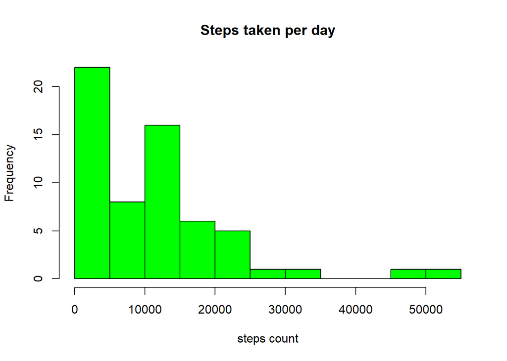

```r
steps_day_2<-tapply(data_input_2$steps,data_input$date,sum,na.rm=TRUE)
hist(steps_day_2,col="green",breaks = 8, xlab = "steps count", main = "Steps taken per day")
```

### Calculate and report the mean and median total number of steps taken per day.

```r
mean_steps_2<-mean(steps_day_2,na.rm=TRUE)
median_steps_2<-median(steps_day_2,na.rm=TRUE)
mean_steps_2
```

```
## [1] 10766.19
```

```r
median_steps_2
```

```
## [1] 10351.62
```

### We need to find out the difference between the two

```r
print("Difference between means")
```

```
## [1] "Difference between means"
```

```r
mean_steps_2 - mean_steps
```

```
## [1] 1411.959
```

```r
print("Difference between medians")
```

```
## [1] "Difference between medians"
```

```r
median_steps_2 - median_steps
```

```
## [1] -43.37736
```

# Are there differences in activity patterns between weekdays and weekends?

For this part the weekdays() function may be of some help here. Use the dataset with the filled-in missing values for this part.

### Create a new factor variable in the dataset with two levels – “weekday” and “weekend” indicating whether a given date is a weekday or weekend day.

```r
data_input_2$weekday<-weekdays(as.Date(as.character(data_input_2$date)))
data_input_2$weekend<-"weekday"
data_input_2[data_input_2$weekday=="sábado" | data_input_2$weekday=="domingo",]$weekend<-"weekend"
data_input_2$weekend<-as.factor(data_input_2$weekend)
```

### Make a panel plot containing a time series plot (i.e. type=“l”) of the 5-minute interval (x-axis) and the average number of steps taken, averaged across all weekday days or weekend days (y-axis).

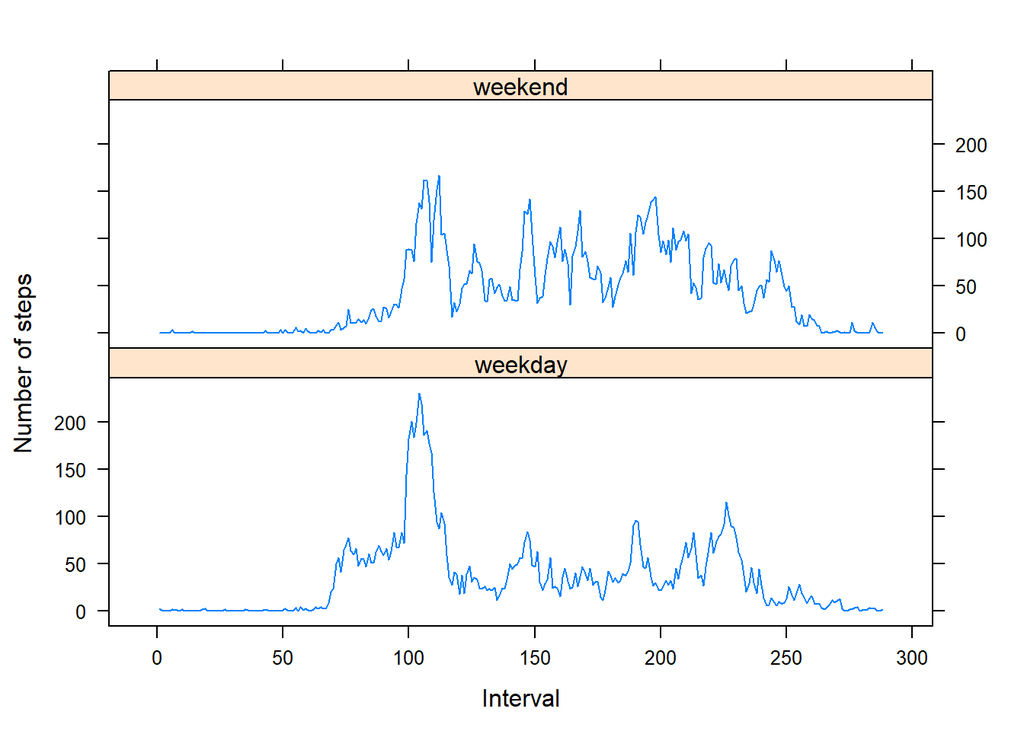

```r
results<-with(data_input_2, tapply(steps, list(interval, weekend), mean,na.rm=TRUE))
resultsdf<-as.data.frame(as.table(results))
resultsdf$Var1<-as.integer(resultsdf$Var1)

library(lattice)
xyplot(Freq ~ Var1|Var2,data=resultsdf,layout=c(1,2),type="l",xlab="Interval",ylab="Number of steps")
```